# Connessioni pericolose: analisi delle interazioni della Mafia Siciliana

Susanna Micoli

10 febbraio 2025

## La Mafia Siciliana

La criminalità organizzata opera attraverso reti di relazioni complesse, basate su vincoli di fiducia, gerarchie e comunicazioni strategiche.

In questa presentazione, utilizzeremo strumenti di Network Analysis per esplorare i dati raccolti nell’ambito dell’Operazione Montagna, un’indagine del 2007 che ha portato alla luce un vasto sistema di connessioni tra membri della Mafia Siciliana.

In particolare, questa indagine si è focalizzata su due clan mafiosi, noti come la “famiglia Mistretta” e il “clan Batanesi”. Queste famiglie infatti, dal 2003 al 2007 si erano infiltrate in numerose attività economiche, tra cui grandi opere infrastrutturali.

La rete Mafiosa ha delle caratteristiche che la rendono unica e diversa dalle altre reti criminali.

Tipicamente le reti terroristiche sono costituite da individui che collaborano per perseguire un obiettivo e che sono disposte a sacrificare le loro vite per portarlo a termine (esempio l’attacco alle Torri Gemelle). Una volta raggiunto l’obiettivo generalmente l’organizzazione terroristica si dissolve.

Un clan mafioso invece dura diverse generazioni ed è caratterizzato da due elementi chiave:

- i legami stretti con gli affiliati
- la capacità di condurre attività illegali per perseguire obiettivi specifici

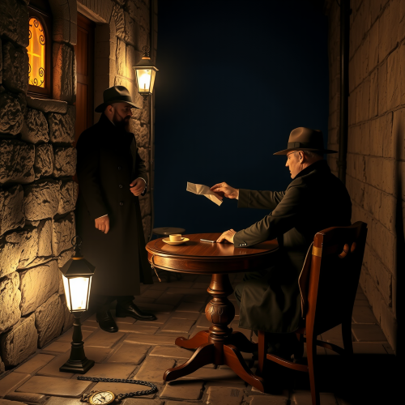

Generated with DALL-E

## Il dataset: reti di incontri e comunicazioni telefoniche

Il dataset, reso disponibile su [Zenodo](https://zenodo.org/records/3938818#.YW4WLhxxWUl), contiene informazioni dettagliate su interazioni fisiche e comunicazioni telefoniche tra i soggetti coinvolti nelle attività mafiose.

Dataset contenente 3 file CSV:

- **Roles**: Ruoli degli indagati e relazioni con altri sospettati
- **Meetings**: Incontri fisici tra i sospettati (documentati tramite appostamenti della polizia). La frequenza degli incontri è rappresentata dalla colonna “weight”
- **Phone Calls**: Telefonate intercettate tra i sospettati. La frequenza delle telefonate è rappresentata dalla colonna “weight”

I nodi nel dataset sono stati anonimizzati, quindi non è possibile identificare direttamente gli individui, ma la struttura delle reti rimane comunque significativa per l’analisi. Le reti che è possibile costruire a partire da questi dataset sono indirette e pesate.

Le reti risultanti per gli incontri fisici e le telefonate sono queste:

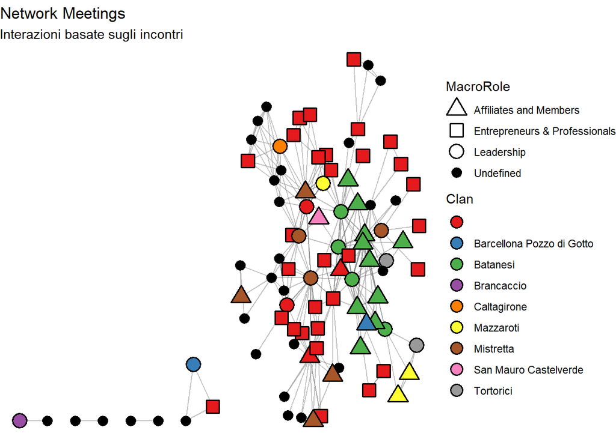

La rete degli incontri con 94 nodi e 284 archi.  
Si nota a destra una componente connessa gigante e componenti più piccole composte da pochissimi nodi a sinistra, questo perchè alcuni dati potrebbero essere mancanti. Spicca subito alla visione la numerosità e la concentrazione dei nodi della famiglia “Batanesi” (in verde), mentre appare più sparsa e meno numerosa la famiglia “Mistretta”.  
Ci sono molti imprenditori e professionisti che possono svolgere ruoli chiave nel supportare le attività dell’organizzazione criminale, fungendo da intermediari tra il mondo legale e quello illegale.

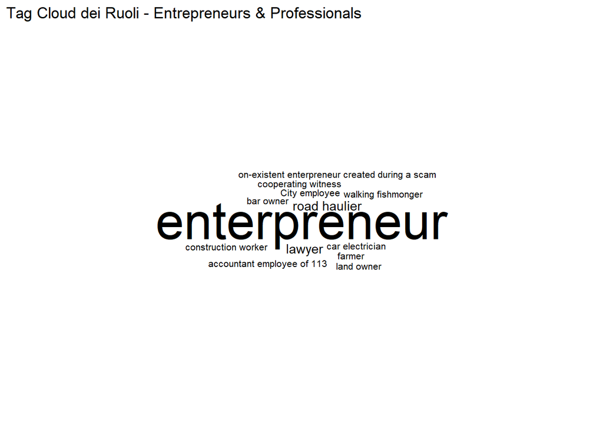

Qui in una piccola tag cloud è possibile vedere nel dettaglio i ruoli più specifici della macro-categoria degli imprenditori. Si parte dal più gettonato e generale imprenditore, all’avvocato, all’autotrasportatore, al contadino fino all’ impiegato contabile presso il 113.

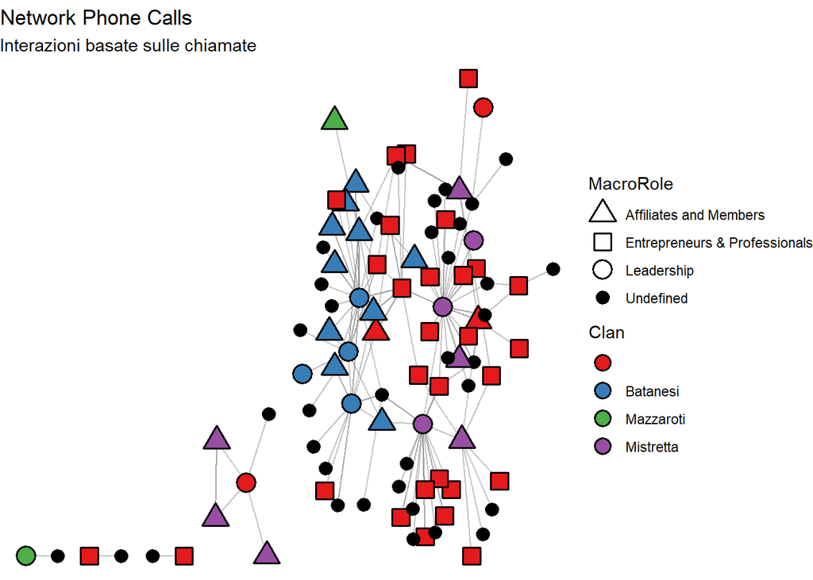

La rete delle telefonate con 94 nodi e 149 archi.  
Sono coinvolte meno famiglie in questa rete e come per la rete degli incontri è possibile notare come le telefonate della “famiglia Batanesi” in blu, siano più raggruppate e coinvolgano più soggetto della stessa famiglia rispetto alla “famiglia Mistretta”.

## Chi sono gli individui che hanno avuto più incontri o telefonate nella rete?

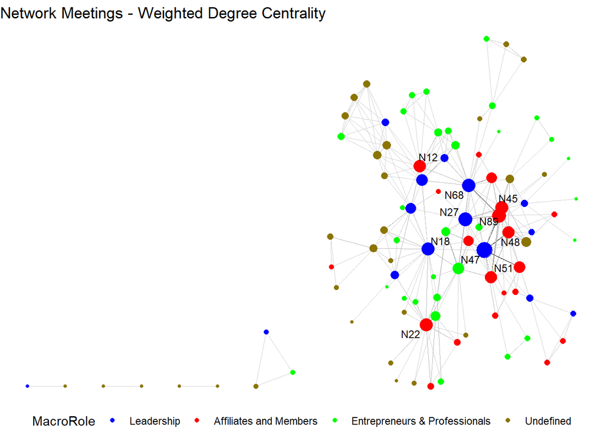

```
## # A tibble: 10 × 4
##    name  Role                            MacroRole              weighted_degree
##    <chr> <chr>                           <chr>                            <dbl>
##  1 N47   deputy boss family ''Batanesi'' Leadership                          65
##  2 N89   member family ''Batanesi''      Affiliates and Members              46
##  3 N27   executive family ''Batanesi''   Leadership                          44
##  4 N68   executive family ''Batanesi''   Leadership                          42
##  5 N22   Pharmacist-member               Affiliates and Members              37
##  6 N45   member family ''Batanesi''      Affiliates and Members              37
##  7 N18   executive family ''Mistretta''  Leadership                          36
##  8 N12   member family ''Mistretta''     Affiliates and Members              35
##  9 N51   member family ''Batanesi''      Affiliates and Members              32
## 10 N48   member family ''Batanesi''      Affiliates and Members              31
```

Sicuramente, osservando la rete e la tabella il vice Boss della famiglia Batanesi (N47) emerge come il nodo più centrale con il più alto weighted degree (65), suggerendo un ruolo chiave nel coordinamento della rete. La famiglia Batanesi appare più strutturata e connessa rispetto alla famiglia Mistretta, con diversi membri che ricoprono ruoli di Leadership o Affiliates and Members, indicando una rete più coesa. Al contrario, la famiglia Mistretta sembra meno influente, con solo due membri tra i più connessi.  
Un caso interessante è il Pharmacist-member (N22), che con un grado pesato di 37 potrebbe fungere da intermediario tra il mondo legale e quello criminale, suggerendo un ruolo strategico nelle attività dell’organizzazione (es. riciclaggio, vendita illegale di farmaci).

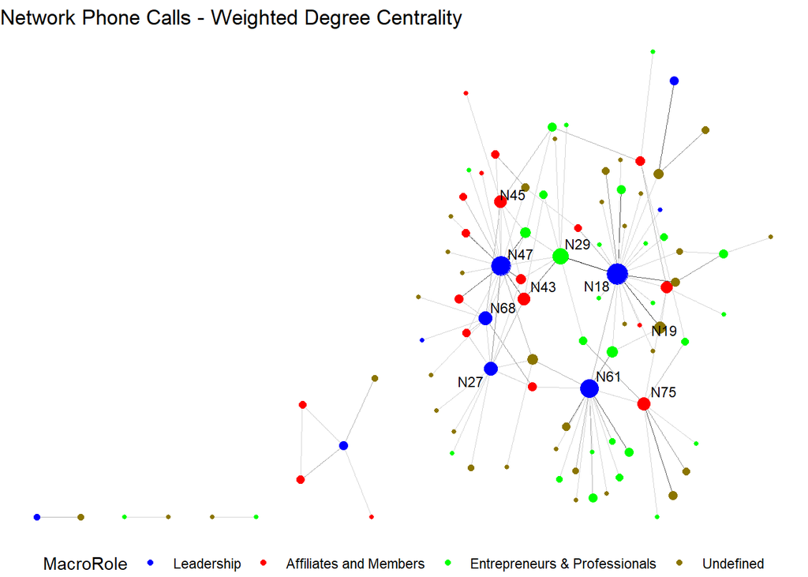

```
## # A tibble: 10 × 4
##    name  Role                              MacroRole             weighted_degree
##    <chr> <chr>                             <chr>                           <dbl>
##  1 N18   "executive family ''Mistretta''"  Leadership                         67
##  2 N47   "deputy boss family ''Batanesi''" Leadership                         55
##  3 N61   "executive family ''Mistretta''"  Leadership                         46
##  4 N29   "enterpreneur"                    Entrepreneurs & Prof…              32
##  5 N27   "executive family ''Batanesi''"   Leadership                         20
##  6 N68   "executive family ''Batanesi''"   Leadership                         20
##  7 N75   "member family ''Mistretta''"     Affiliates and Membe…              17
##  8 N43   "intermediator"                   Affiliates and Membe…              15
##  9 N45   "member family ''Batanesi''"      Affiliates and Membe…              15
## 10 N19   ""                                Undefined                          13
```

In questa rete, la famiglia Mistretta mostra una leadership più connessa, con N18 (Executive, 67) come nodo più centrale, seguito da N61 (Executive, 46). Al contrario, la famiglia Batanesi ha una presenza meno connessa ai vertici, con il Deputy Boss (N47, 55) e altri executive con valori più bassi. Spicca N29 (Entrepreneur, 32), segnalando il possibile ruolo strategico di imprenditori nel collegare il mondo criminale e quello legale. Anche gli affiliati partecipano alla rete, mentre figure come N43 (Intermediator, 15) suggeriscono connessioni esterne rilevanti.

Sembra quindi che la famiglia Mistretta prediliga le telefonate, mentre la famiglia Batanesi preferisca incontri segreti di persona.

## Esistono pochi nodi altamente connessi o il peso è distribuito in modo omogeneo?

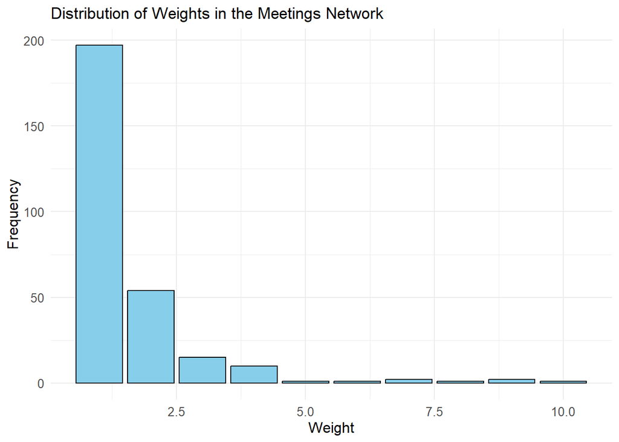

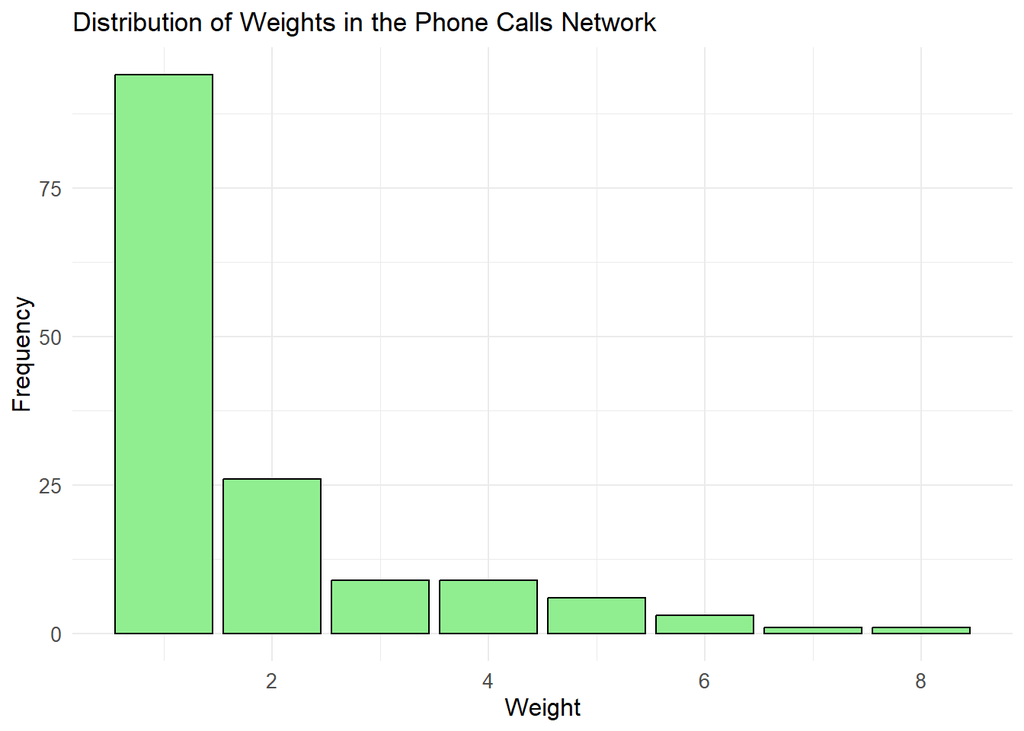

L’analisi della distribuzione dei gradi mostra che la rete segue una distribuzione esponenziale, con la maggior parte dei nodi che ha poche connessioni e solo alcuni nodi (gli hub) con un numero molto elevato di connessioni. Le reti scale-free presentano questi hub che mantengono la lunghezza media dei cammini bassa, facilitando la circolazione delle informazioni. Sebbene siano resistenti alla rimozione casuale di nodi, queste reti sono vulnerabili alla perdita degli hub, che compromette la connettività e il flusso delle informazioni.  
Nella rete degli incontri, ci sono più nodi con pochi collegamenti rispetto alla rete delle telefonate (quasi il doppio).  
Il peso massimo della rete degli incontri è 10, suggerendo che i mafiosi preferiscono incontri fisici per ridurre il rischio di intercettazioni (più semplice criptare le conversazioni e usare il linguaggio del corpo).  
I nodi con grado più alto hanno ruolo di leadership, questo si conferma con il fatto che i capi spesso devono partecipare agli eventi mafiosi per perseguire e confermare il loro potere all’interno di un clan. Ad esempio, i capi devono partecipare ai funerali di altri affiliati o ad altre manifestazioni solenni. Durante questo tipo di eventi, hanno anche l’opportunità di trasmettere messaggi ai loro più stretti affiliati subordinati.

## Chi ha il ruolo di “collegamento” nella rete?

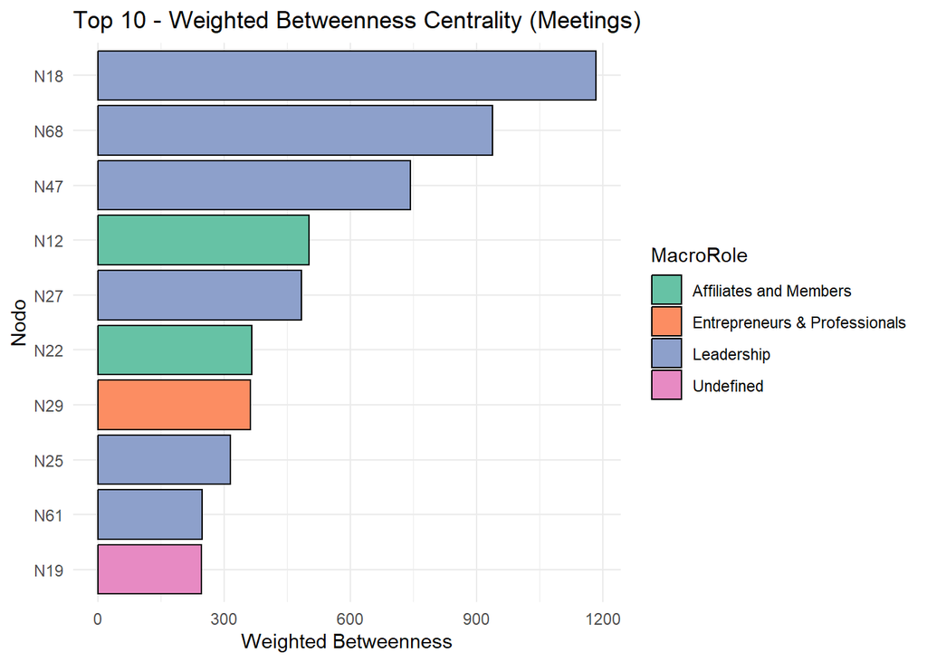

```
## # A tibble: 10 × 4
##    name  Role                              MacroRole                 betweenness
##    <chr> <chr>                             <chr>                           <dbl>
##  1 N18   "executive family ''Mistretta''"  Leadership                      1183.
##  2 N68   "executive family ''Batanesi''"   Leadership                       938.
##  3 N47   "deputy boss family ''Batanesi''" Leadership                       743.
##  4 N12   "member family ''Mistretta''"     Affiliates and Members           502.
##  5 N27   "executive family ''Batanesi''"   Leadership                       483.
##  6 N22   "Pharmacist-member"               Affiliates and Members           365.
##  7 N29   "enterpreneur"                    Entrepreneurs & Professi…        362.
##  8 N25   "executive family ''Mistretta''"  Leadership                       316.
##  9 N61   "executive family ''Mistretta''"  Leadership                       247.
## 10 N19   ""                                Undefined                        247.
```

Non è stato utilizzato il peso degli archi nel calcolo della betweenness centrality, poiché sarebbe stato interpretato come una distanza anziché come una frequenza dei collegamenti, modificando così l’interpretazione dei dati.

Dall’analisi emerge chiaramente che i membri con ruoli di leadership sono quelli con i valori di betweenness più alti, indicando che sono i principali “collegamenti” tra gli altri nodi. Per esempio, il nodo N18, che rappresenta un esponente di alto livello della famiglia Mistretta, ha il valore di betweenness più alto (1183.04), seguito da N68 e N47, che sono rispettivamente i leader delle famiglie Batanesi e il vice-capo della stessa famiglia. Questi nodi sono i punti di riferimento principali per il flusso delle informazioni e l’organizzazione interna.  
Anche i membri di secondo piano, come il N12 (membro della famiglia Mistretta) e il N22 (farmacista affiliato), sebbene con valori di betweenness più bassi, sono comunque nodi significativi, fungendo da ponti tra i livelli più alti della rete e i membri più periferici. Ad esempio, il N22 potrebbe agire come intermediario tra i clan e il mondo esterno, come suggerito dal suo ruolo di farmacista.  
Infine, ci sono nodi che, pur avendo un ruolo meno centrale, sono comunque importanti nella struttura complessiva della rete. Il N29, un entrepreneur, pur avendo un valore di betweenness più basso (361.90), potrebbe svolgere un ruolo essenziale come connettore in specifiche aree della rete economica o professionale.

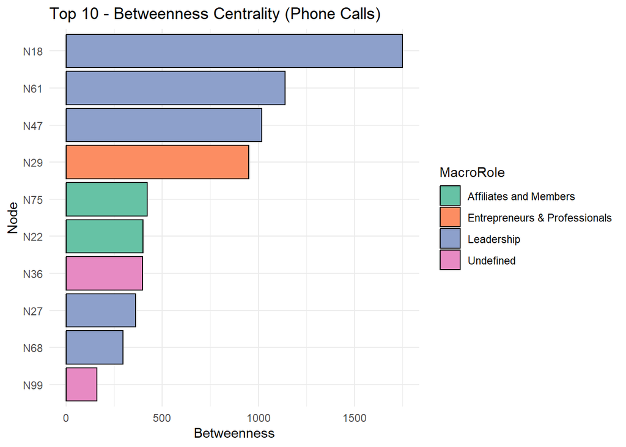

```
## # A tibble: 10 × 4
##    name  Role                              MacroRole                 betweenness
##    <chr> <chr>                             <chr>                           <dbl>
##  1 N18   "executive family ''Mistretta''"  Leadership                      1748.
##  2 N61   "executive family ''Mistretta''"  Leadership                      1138.
##  3 N47   "deputy boss family ''Batanesi''" Leadership                      1018.
##  4 N29   "enterpreneur"                    Entrepreneurs & Professi…        949.
##  5 N75   "member family ''Mistretta''"     Affiliates and Members           423.
##  6 N22   "Pharmacist-member"               Affiliates and Members           401.
##  7 N36   ""                                Undefined                        397.
##  8 N27   "executive family ''Batanesi''"   Leadership                       362.
##  9 N68   "executive family ''Batanesi''"   Leadership                       296.
## 10 N99   ""                                Undefined                        161
```

L’analisi della betweenness centrality nella rete delle telefonate mostra che i nodi con ruoli di leadership continuano a essere i più centrali nella rete, facilitando il flusso delle informazioni. In particolare, il nodo N18 (executive della famiglia Mistretta) ha il valore più alto di betweenness (1748.11), seguito da N61 (1138.33) e N47, il vice-capo della famiglia Batanesi (1017.82).  
Un risultato interessante è l’alta centralità di N29, un entrepreneur (949.27), che potrebbe indicare un ruolo chiave nel collegamento tra la sfera criminale e il mondo economico. Anche il farmacista N22 e il membro N75 della famiglia Mistretta mostrano una betweenness rilevante, suggerendo la loro importanza come intermediari nella comunicazione.  
Infine, i nodi N36 e N99, senza un ruolo definito, hanno una betweenness significativa, il che potrebbe indicare un ruolo nascosto o di supporto nella rete.

## Chi può diffondere le informazioni più rapidamente all’interno della rete?

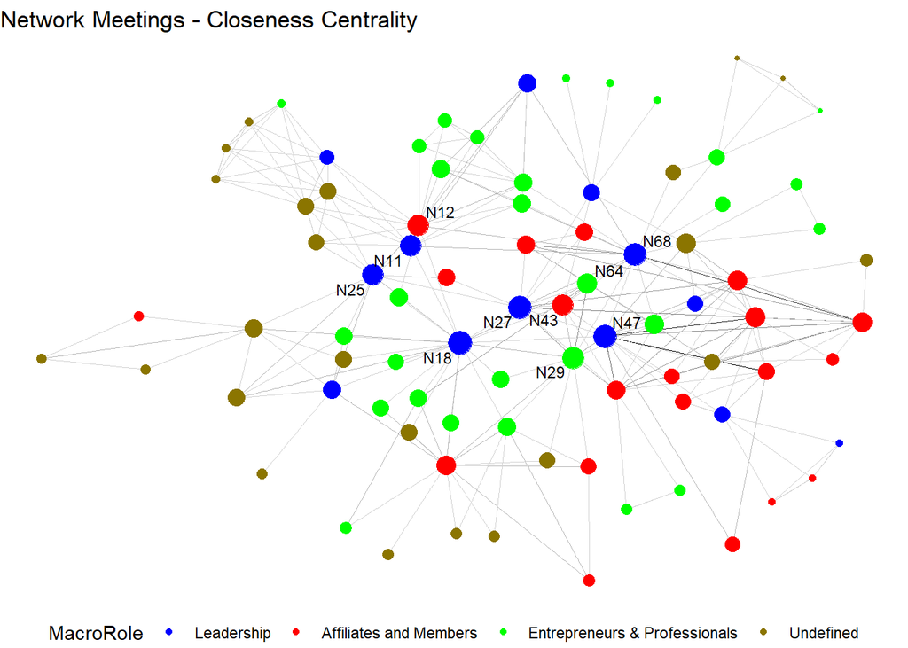

```
## # A tibble: 10 × 4
##    name  Role                            MacroRole                     closeness
##    <chr> <chr>                           <chr>                             <dbl>
##  1 N18   executive family ''Mistretta''  Leadership                      0.00585
##  2 N27   executive family ''Batanesi''   Leadership                      0.00559
##  3 N47   deputy boss family ''Batanesi'' Leadership                      0.00556
##  4 N68   executive family ''Batanesi''   Leadership                      0.00552
##  5 N29   enterpreneur                    Entrepreneurs & Professionals   0.00535
##  6 N43   intermediator                   Affiliates and Members          0.00515
##  7 N12   member family ''Mistretta''     Affiliates and Members          0.00513
##  8 N11   boss Cosa Nostra in Messina     Leadership                      0.00503
##  9 N25   executive family ''Mistretta''  Leadership                      0.00503
## 10 N64   enterpreneur                    Entrepreneurs & Professionals   0.00476
```

È stata considerata solo la componente gigante perché la closeness centrality si basa sulle distanze tra i nodi e ha senso calcolarla solo tra nodi che possono effettivamente raggiungersi. Le componenti più piccole avrebbero potuto falsare l’interpretazione.  
Inoltre anche per questa misura si è preferito non considerare il peso sugli archi perché sarebbe stato interpretato nella misura come distanza e non come frequenza.

L’analisi della closeness centrality nella rete degli incontri mostra che i leader delle famiglie Mistretta e Batanesi occupano posizioni centrali, facilitando la comunicazione e il coordinamento all’interno dell’organizzazione. Oltre ai capi e ai loro vice, anche alcuni imprenditori, come N29 e N64, ricoprono un ruolo strategico, probabilmente fungendo da ponte tra la rete criminale e il mondo economico.  
Un altro nodo rilevante è N43, un intermediario che potrebbe agevolare il flusso di informazioni tra affiliati e vertici. Inoltre, la presenza del boss di Cosa Nostra a Messina (N11) tra i nodi con il valore più alto di closeness suggerisce che la rete non sia limitata a una singola area geografica, ma abbia connessioni più ampie.  
Il boss di Cosa Nostra a Messina (N11) non è emerso tra i nodi con il valore più alto di degree centrality o betweenness centrality perché probabilmente il suo ruolo nella rete non è quello di mantenere molte connessioni dirette o di fungere da ponte tra diverse comunità. Invece, il suo valore elevato di closeness centrality suggerisce che, pur avendo un numero relativamente limitato di collegamenti, è strategicamente posizionato per raggiungere rapidamente tutti gli altri membri della rete.  
Questo potrebbe riflettere un modello tipico delle organizzazioni mafiose, dove i boss tendono a mantenere un profilo basso per ridurre il rischio di essere intercettati, delegando la gestione operativa a intermediari fidati. Il loro potere non deriva dalla quantità di connessioni dirette, ma dalla capacità di accedere rapidamente alle informazioni e influenzare la rete senza essere un punto di snodo evidente.  
Questi risultati indicano che la struttura mafiosa è progettata per garantire una comunicazione efficiente tra i vari livelli dell’organizzazione, con una combinazione di leader, intermediari e figure economiche in posizioni strategiche.

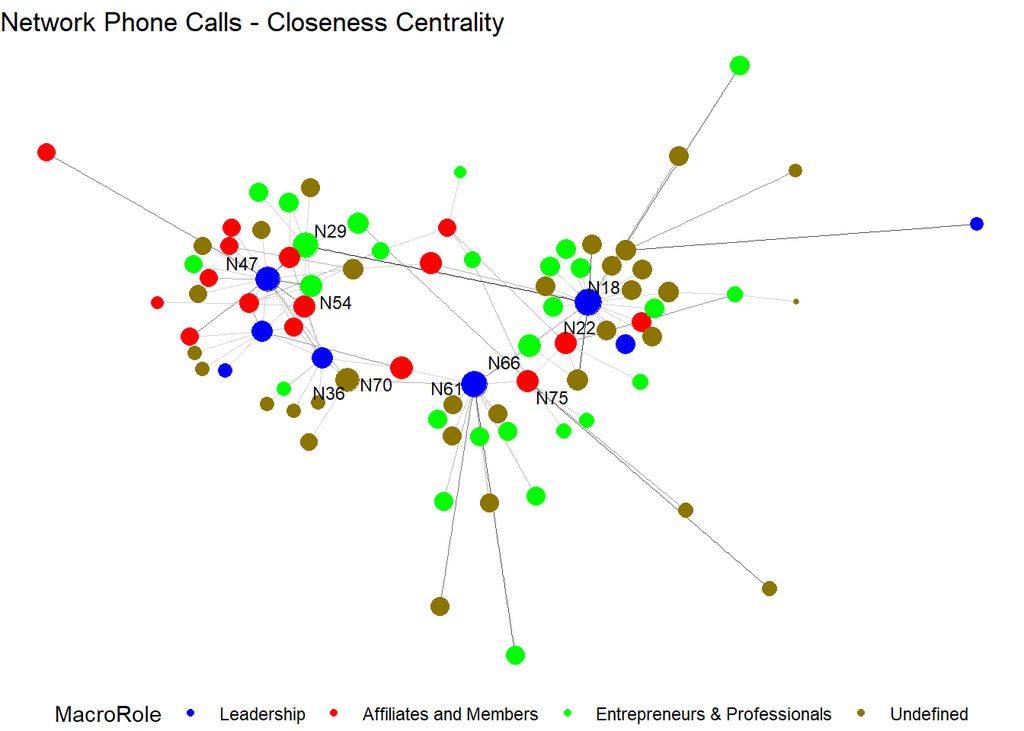

```
## # A tibble: 10 × 4
##    name  Role                              MacroRole                   closeness
##    <chr> <chr>                             <chr>                           <dbl>
##  1 N18   "executive family ''Mistretta''"  Leadership                    0.00562
##  2 N61   "executive family ''Mistretta''"  Leadership                    0.00538
##  3 N29   "enterpreneur"                    Entrepreneurs & Profession…   0.00526
##  4 N47   "deputy boss family ''Batanesi''" Leadership                    0.00495
##  5 N36   ""                                Undefined                     0.00474
##  6 N70   "member family ''Batanesi''"      Affiliates and Members        0.00450
##  7 N66   "enterpreneur"                    Entrepreneurs & Profession…   0.00439
##  8 N22   "Pharmacist-member"               Affiliates and Members        0.00433
##  9 N54   "enterpreneur"                    Entrepreneurs & Profession…   0.00433
## 10 N75   "member family ''Mistretta''"     Affiliates and Members        0.00429
```

L’analisi della closeness centrality nella rete delle telefonate rivela che i nodi più centrali appartengono a una varietà di ruoli, ma con una netta prevalenza di figure di leadership, imprenditori e alcuni membri affiliati. I due nodi che emergono con i valori più alti di closeness sono N18 e N61, entrambi legati alla famiglia Mistretta. Questo suggerisce che queste figure siano tra le più efficienti nel diffondere informazioni all’interno della rete, giocando un ruolo cruciale nella comunicazione e nel coordinamento delle attività.  
Al terzo posto troviamo N29, un imprenditore, che si posiziona come un nodo strategico, probabilmente grazie alla sua posizione che gli consente di collegare vari membri della rete. Anche N47, il deputy boss della famiglia Batanesi, occupa una posizione centrale con un valore elevato di closeness, confermando la sua importanza all’interno della struttura comunicativa, dove svolge probabilmente un ruolo di mediazione tra diversi gruppi.

Le telefonate servono a coordinare l’attività quotidiana e il flusso di informazioni in modo rapido ed efficiente, gli incontri sono probabilmente utilizzati per consolidare alleanze, discutere piani importanti e gestire relazioni più intime o delicate, con una maggiore partecipazione delle figure apicali della rete.

Questi risultati indicano che la struttura mafiosa è progettata per garantire una comunicazione efficiente tra i vari livelli dell’organizzazione, con una combinazione di leader, intermediari e figure economiche in posizioni strategiche.

## I nodi con molte connessioni sono sempre i più influenti, anche considerando i nodi a cui sono collegati?

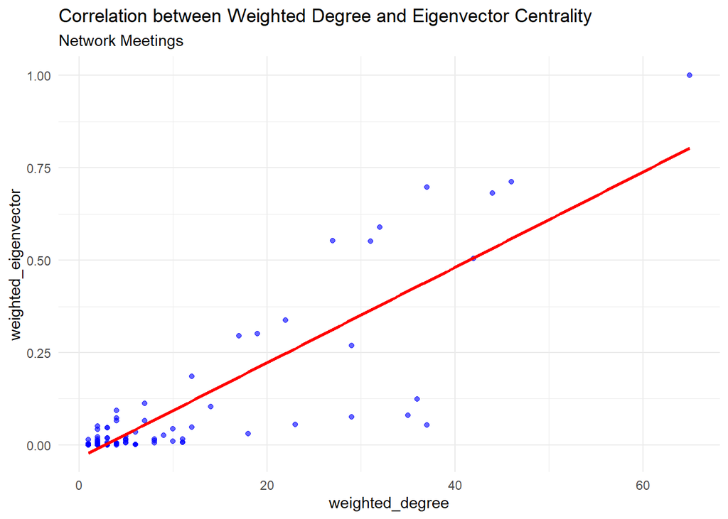

Qui la correlazione è più alta, il che significa che i nodi con molte connessioni (weighted degree) tendono ad avere anche un’alta influenza nella rete (weighted eigenvector). Questo suggerisce che negli incontri fisici, chi è molto connesso è probabilmente anche centrale nel flusso di informazioni e nelle dinamiche di potere.

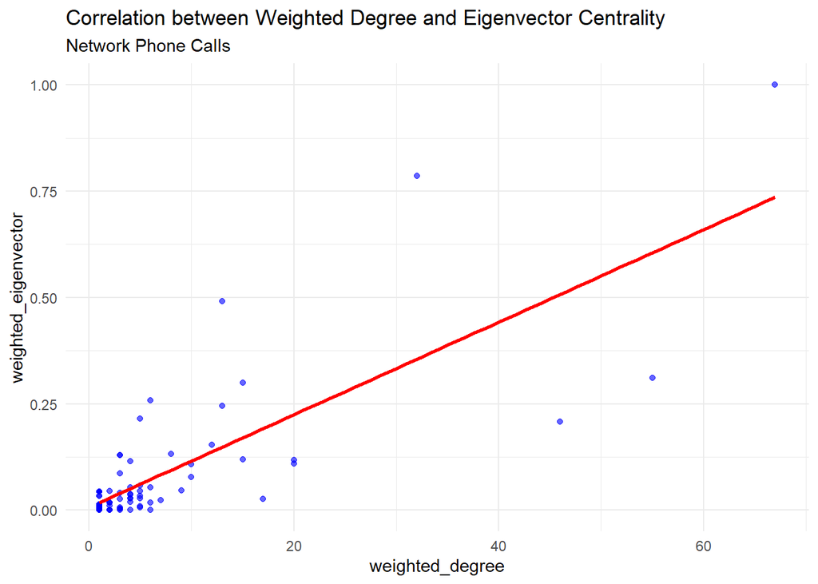

La correlazione è più debole, indicando che avere molte connessioni non implica necessariamente un’alta influenza. Questo potrebbe dipendere dal fatto che le telefonate sono più distribuite tra diversi attori, con una maggiore eterogeneità nei ruoli e nelle connessioni.

## Le reti degli incontri e delle telefonate seguono le stesse dinamiche comunicative o rispondono a esigenze diverse?

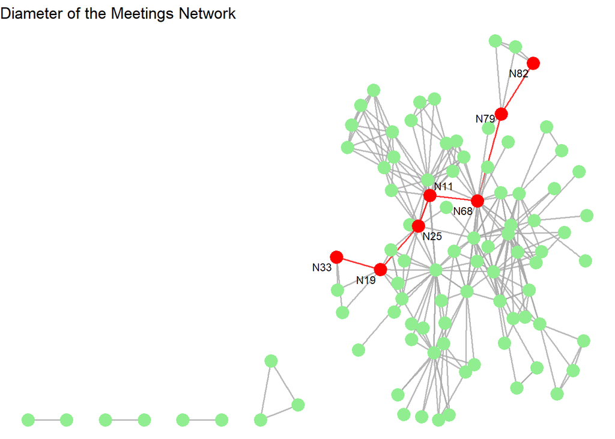

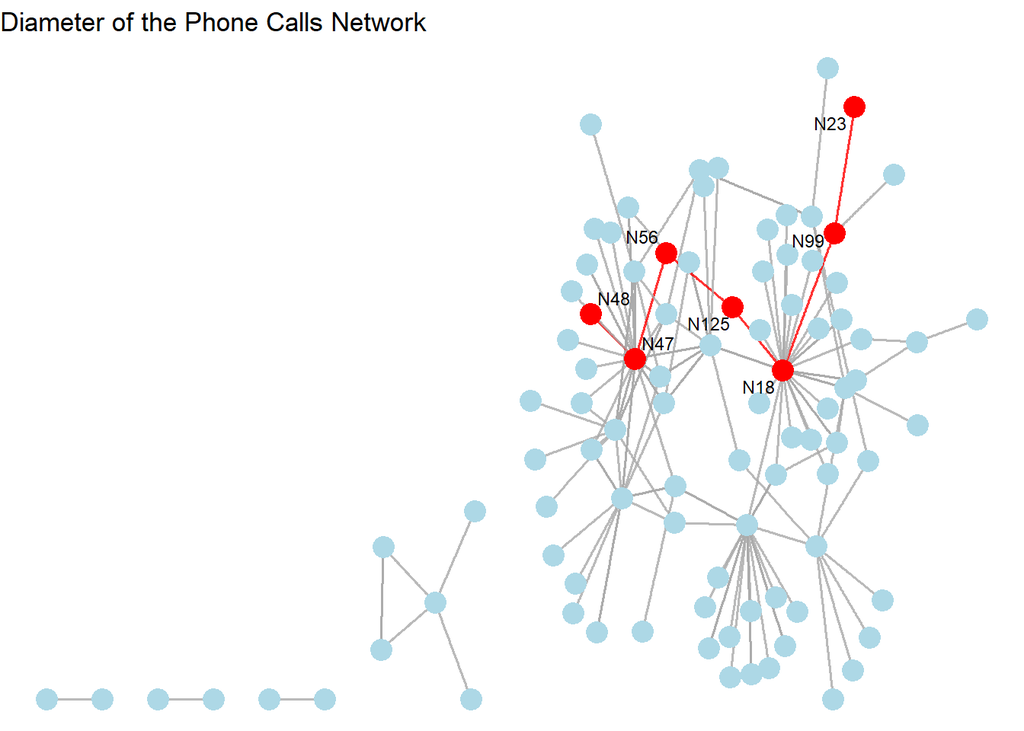

## Come varia la distribuzione delle lunghezze dei percorsi più brevi all’interno della rete?

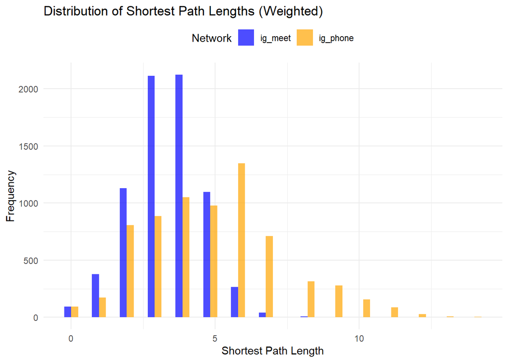

L’istogramma mostra la distribuzione delle lunghezze dei cammini minimi pesati per due reti: la rete degli incontri in blu e la rete delle chiamate in giallo.  
Le osservazioni principali emergono chiaramente quando confrontiamo le due reti. La rete degli incontri presenta una distribuzione più concentrata su lunghezze di cammino più brevi. Questo indica che, all’interno di questa rete, le informazioni tendono a diffondersi in modo più rapido ed efficiente. Probabilmente, la presenza di molti collegamenti diretti tra i nodi facilita il passaggio delle informazioni, suggerendo una struttura di rete più coesa.  
Al contrario, la rete delle telefonate mostra una distribuzione più ampia, con cammini minimi che raggiungono lunghezze maggiori. Questo suggerisce che, nella rete telefonica, la comunicazione è più dispersa e meno diretta, con alcune informazioni che devono attraversare più intermediari per arrivare ai destinatari. Potrebbe essere che la rete telefonica sia strutturata in modo da ridurre il rischio di intercettazioni o di identificazione di nodi chiave, mantenendo così una maggiore sicurezza o compartimentazione nella comunicazione.  
Si può notare che in entrambe le reti non esistono cammini né troppo corti né troppo lunghi, indicando una maggiore frequenza di interazioni tra gli affiliati che si trovano in posizioni intermedie. Questo comportamento conferma l’ipotesi che all’interno di un clan sia meglio evitare i casi limite. Da un lato se il percorso più breve è composto da un numero basso di affiliati, i capi sono sovraesposti alle indagini della polizia. D’altra parte, più lungo è il numero di intermediari, maggiori sono le possibilità di essere intercettati da persone al di fuori della famiglia.  
Inoltre, emerge una minore frequenza di interazioni nell’insieme di dati delle chiamate telefoniche rispetto che quella degli incontri. Questo comportamento, dimostra che il clan cerca di minimizzare il rischio di intercettazioni, specialmente per evitare di esporre i membri che sono gerarchicamente in un rango più alto.

## Quali sono i nodi in comune?

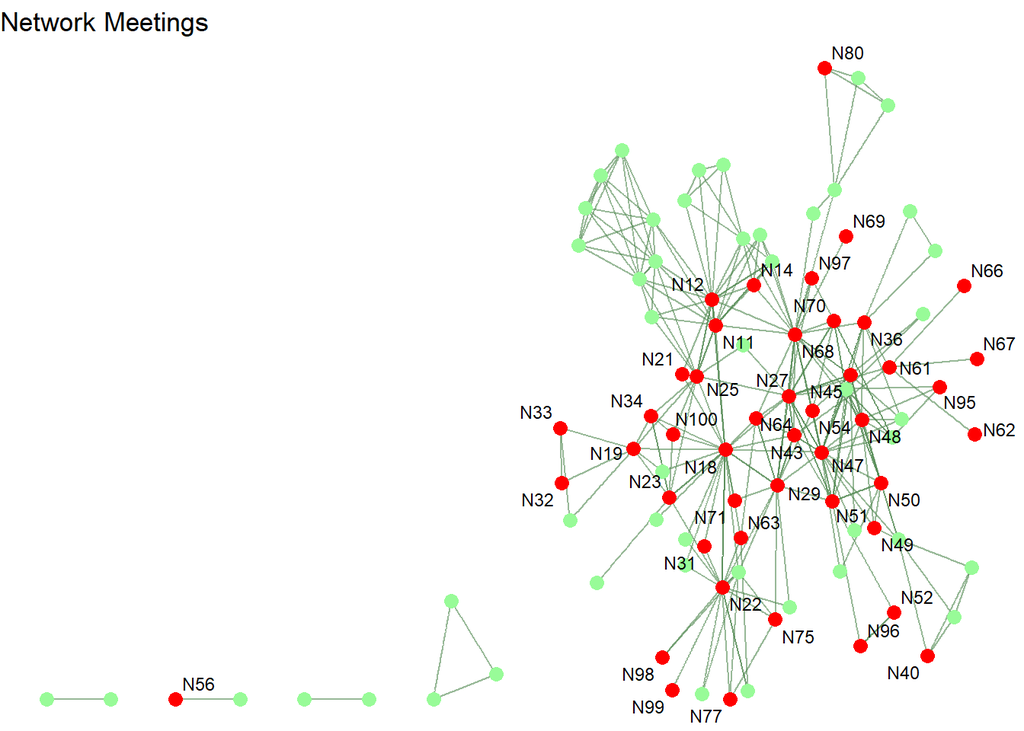

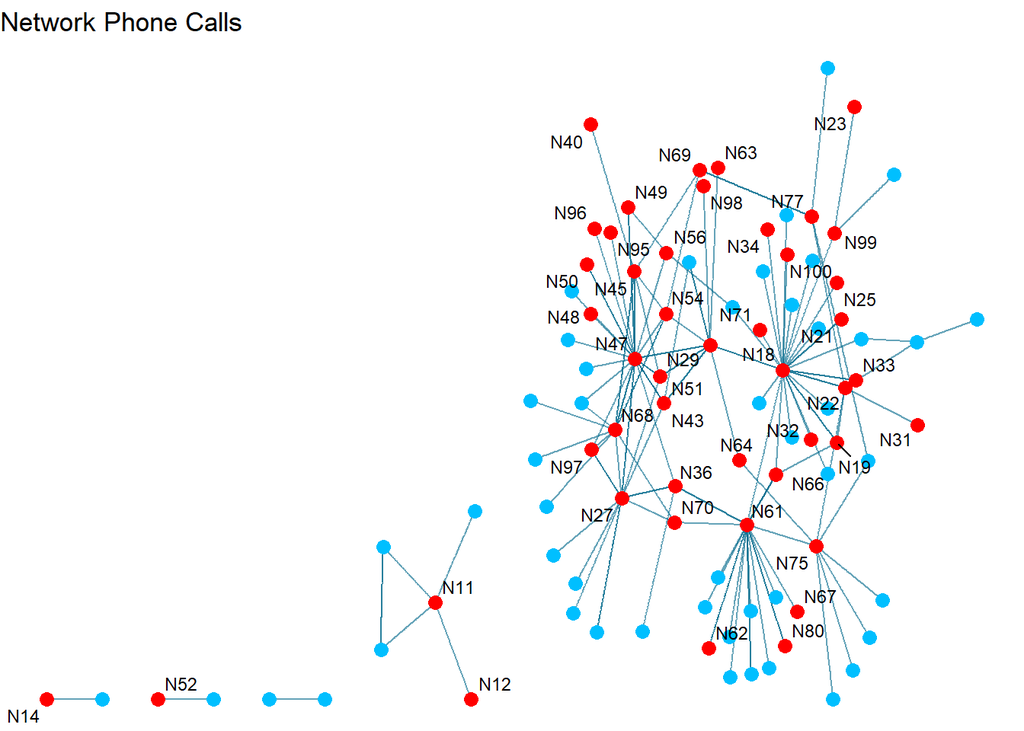

Si nota come la maggior parte dei nodi, in entrambe le reti siano centrali alla componente connessa gigante.

## Quali macro-ruoli sono più frequentemente soggetti ad arresto tra i nodi in comune?

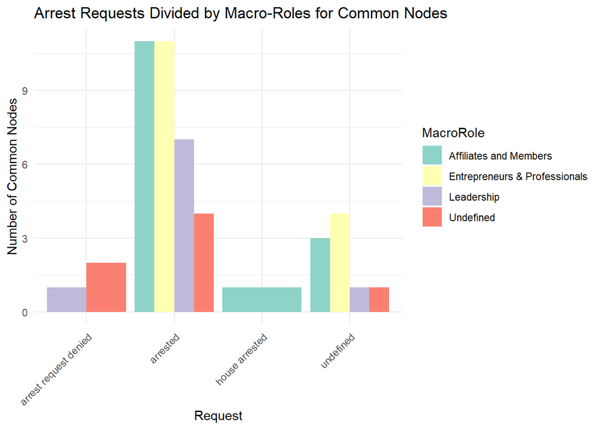

```
## # A tibble: 6 × 5
##   name  Request  Role                            MacroRole  weighted_degree
##   <chr> <chr>    <chr>                           <chr>                <dbl>
## 1 N47   arrested deputy boss family ''Batanesi'' Leadership              65
## 2 N27   arrested executive family ''Batanesi''   Leadership              44
## 3 N68   arrested executive family ''Batanesi''   Leadership              42
## 4 N18   arrested executive family ''Mistretta''  Leadership              36
## 5 N25   arrested executive family ''Mistretta''  Leadership              23
## 6 N23   arrested executive family                Leadership              11
```

```
## # A tibble: 6 × 5
##   name  Request  Role                        MacroRole           weighted_degree
##   <chr> <chr>    <chr>                       <chr>                         <dbl>
## 1 N22   arrested Pharmacist-member           Affiliates and Mem…              37
## 2 N45   arrested member family ''Batanesi''  Affiliates and Mem…              37
## 3 N12   arrested member family ''Mistretta'' Affiliates and Mem…              35
## 4 N51   arrested member family ''Batanesi''  Affiliates and Mem…              32
## 5 N48   arrested member family ''Batanesi''  Affiliates and Mem…              31
## 6 N50   arrested member family ''Batanesi''  Affiliates and Mem…              27
```

La maggior parte degli arresti riguarda i ruoli di membri e affiliati e imprenditori.  
Gli individui arrestati sono anche i nodi più importanti rappresentati nelle visualizzazioni precedenti.  
Anche il nodo N22 rientra tra gli individui arrestati. Questo conferma la sua vicinanza alle attività mafiose.

## Quale metrica è più efficace nel disgregare la rete?

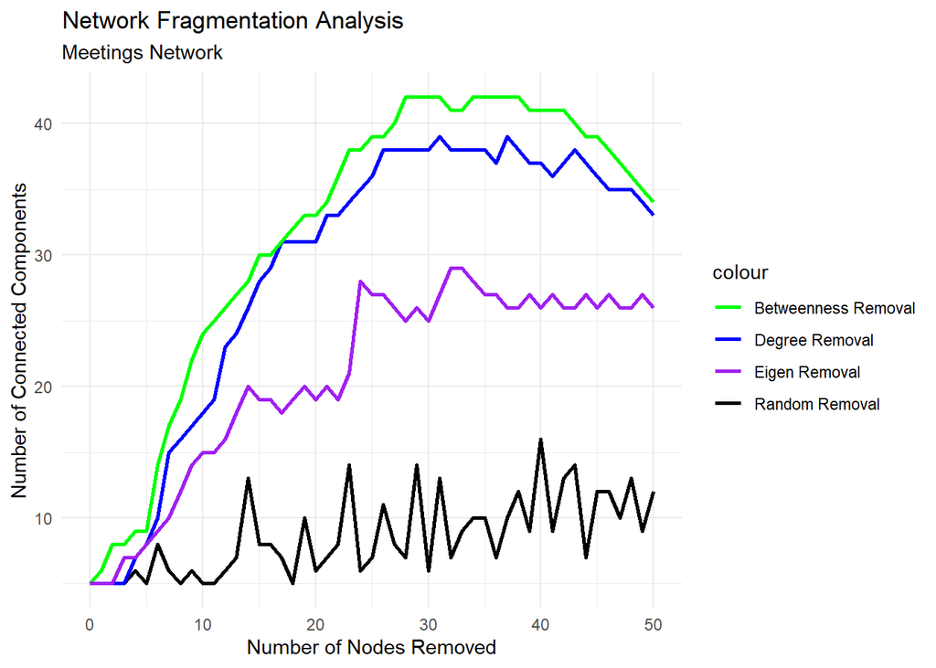

Per la rete degli incontri, eliminare un nodo alla volta scegliendo la metrica “betweenness centrality” risulta essere la scelta migliore, poiché porta rapidamente alla frammentazione della rete. Seguita dalla strategia di rimuovere i nodi con grado maggiore. Questo suggerisce che la rete è fortemente dipendente da pochi hub con molte connessioni.  
La rimozione casuale è la scelta peggiore perché i nodi scelti casualmente non tengono conto di informazioni importanti di un nodo, quale l’importanza, la centralità, l’influenza dei vicini, ecc. Questo conferma che la rete ha una struttura non casuale, con alcuni nodi molto più importanti di altri.

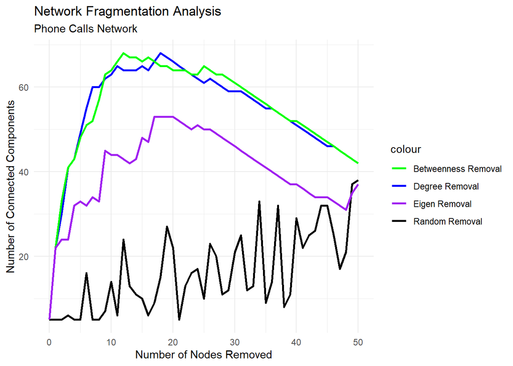

## Conclusioni

L’analisi delle due reti, quella degli incontri e quella delle telefonate, rivela una struttura gerarchica e strategica, con i nodi di leadership e affiliati che giocano un ruolo cruciale nel mantenere la coesione e la diffusione delle informazioni all’interno della rete mafiosa. La rete degli incontri risulta più compatta e diretta, favorendo comunicazioni rapide e riservate, mentre la rete delle telefonate è più dispersa, utilizzata probabilmente per mantenere maggiore sicurezza e ridurre il rischio di intercettazioni. Le telefonate facilitano il coordinamento delle attività quotidiane e il rapido scambio di informazioni, mentre gli incontri servono probabilmente a rafforzare alleanze, discutere strategie cruciali e gestire relazioni riservate, coinvolgendo maggiormente le figure di vertice della rete. La centralità dei nodi chiave, come i leader e gli imprenditori, è confermata da metriche di centralità e betweenness, indicando che questi attori sono essenziali per il funzionamento della rete. Infine, l’analisi della rimozione dei nodi mostra come la rete sia altamente dipendente da pochi hub centrali, suggerendo una struttura non casuale e vulnerabile alla perdita di questi nodi strategici. In generale, entrambe le reti rivelano un equilibrio tra efficienza comunicativa e sicurezza, con i nodi più importanti esposti a un rischio maggiore di arresto.

> **“La lotta alla mafia dev’essere innanzitutto un movimento culturale che abitui tutti a sentire la bellezza del fresco profumo della libertà che si oppone al puzzo del compromesso morale, dell’indifferenza, della contiguità e quindi della complicità.”**  
> — *Paolo Borsellino*

Grazie per l’attenzione.

Susanna Micoli